# TAC vs ITQ, Results

Ernesto Carrella

October 27, 2015

## Policy does not affect locational choice in a one species world

Take a world with fixed biology with a single specie and the farther one goes from port the more biomass he finds.  
There is an profit-maximizing spot where one should go fishing which corresponds to the right tradeoff between transportation costs and time and fish abundance.  
Different policies do not affect this: regardless of whether fishing is unregulated, subject to a global quota or an ITQ, fishers always prefer fishing at their favorite spot.  
This is easily seen in the “heatmap” showing the relative distribution of tows over a 5 year period, in all cases a single peak (at optimal point) dominates everything else (green is land).

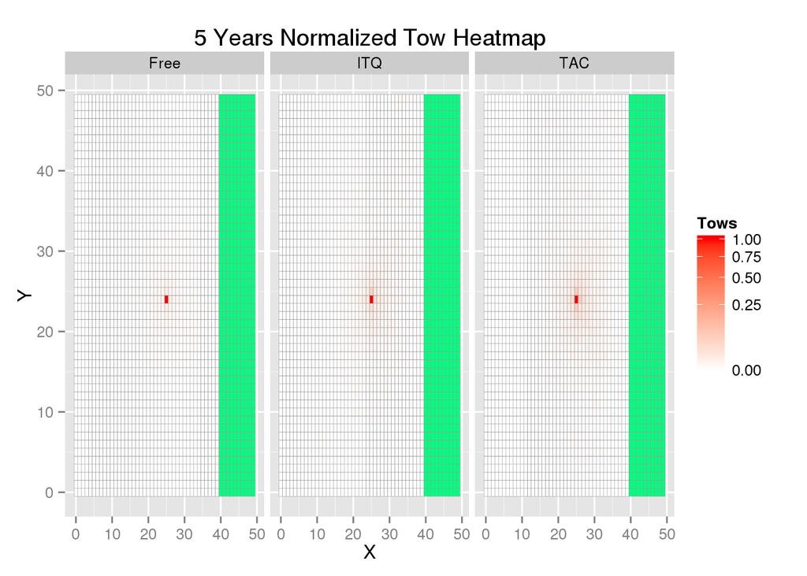

## Policy affects locational choice in a two specie world

Now take the more standard world where each cell is its own logistic factory There are two species of fish: red fish live everywhere, blue fish live only on the bottom half of the sea. Both are valuable and in the south red and fish occur on a 1:1 proportion.  
In general fishers prefer to fish south (since there are twice as many fish) but we can implement policies that protect the blues.  
I set up a TAC that allows for 400,000 red fish and 100,000 blue fish to be caught each year (and as soon as one quota is breached the season stops) and compare it to an ITQ with the same numbers and a scenario with no regulation whatsoever.

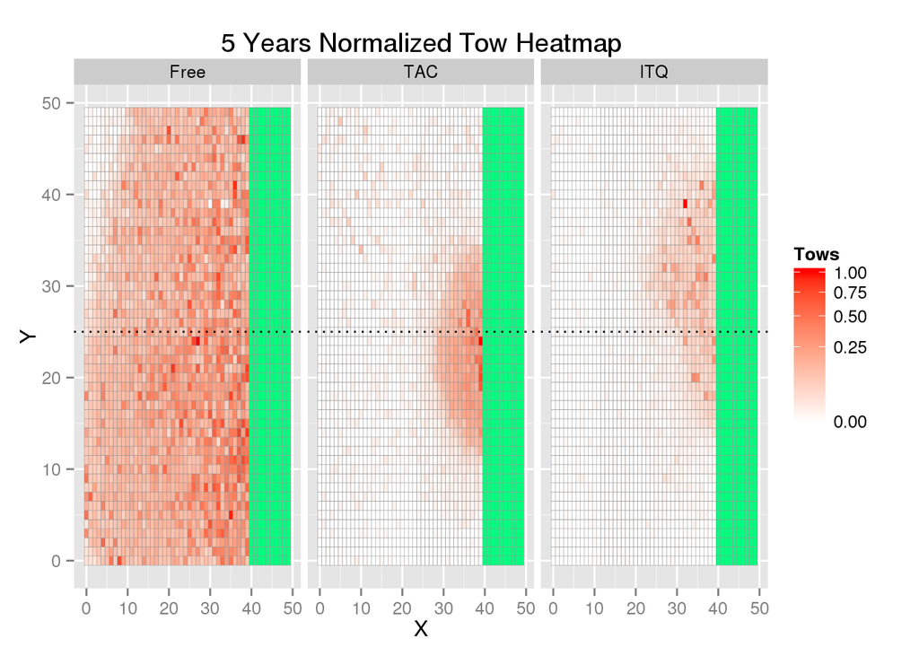

As you can see from the heatmap, unregulated agents eventually fish all over the map (as they progressively consume anything close to port) but the most interesting comparison is between TAC and ITQ.  
With TACs agents fish close to port but mostly south (where there are both blue and red fish) even though blues are protected. Instead with ITQs fishers tend to fish north in order to avoid paying for blue quotas (which must get very expensive).  
ITQs then can steer fishers while TACs don’t.

## TACs are technically efficient

This is an interesting result which is actually just a consequence of the biomass setup.  
TACs dynamics are simple: seasons are very short as people quickly finish up the blue quota. This means that a lot of fish is still in the sea and reproducing. Hence fish is always plentiful near port and very little exploration can truly fail. Eventually then fishers under TAC make the most $ per unit of gas consumed, in spite of being the scenario with the least amount of catches.

Cumulative Statistics For a 5 Year Simulation Run

| Policy | Red Catches | Blue Catches | Fuel Consumed | Total Earnings | Earnings Per Liter |
| --- | --- | --- | --- | --- | --- |
| tac | 937147.7 | 500000.0 | 9556024 | 14371477 | 1.5039180 |
| itq | 1534360.9 | 358425.8 | 17831996 | 18927867 | 1.0614553 |
| free | 6419626.1 | 3226669.4 | 158584079 | 96462954 | 0.6082764 |

Notice also how no regulation has the least amount of earnings per unit of fuel. This is because fishers quickly consume biomass close to port so on average they have to make longer trips for the same catch.

## ITQs seem to be correlated to higher inequality

I think we should embargo this result until we understand better what is actually driving the results here. It might be the way agents form predictions, how they price their quotas or just some silly bug.

So far though, the results are as follows: ITQs have a much more spread out distribution of yearly income compared to the non-regulated and the TAC scenario. This is in spite of everyone having the same gear and ability. It might be that the market multiplies the small variations due to exploration luck into large differences of quota valuations.

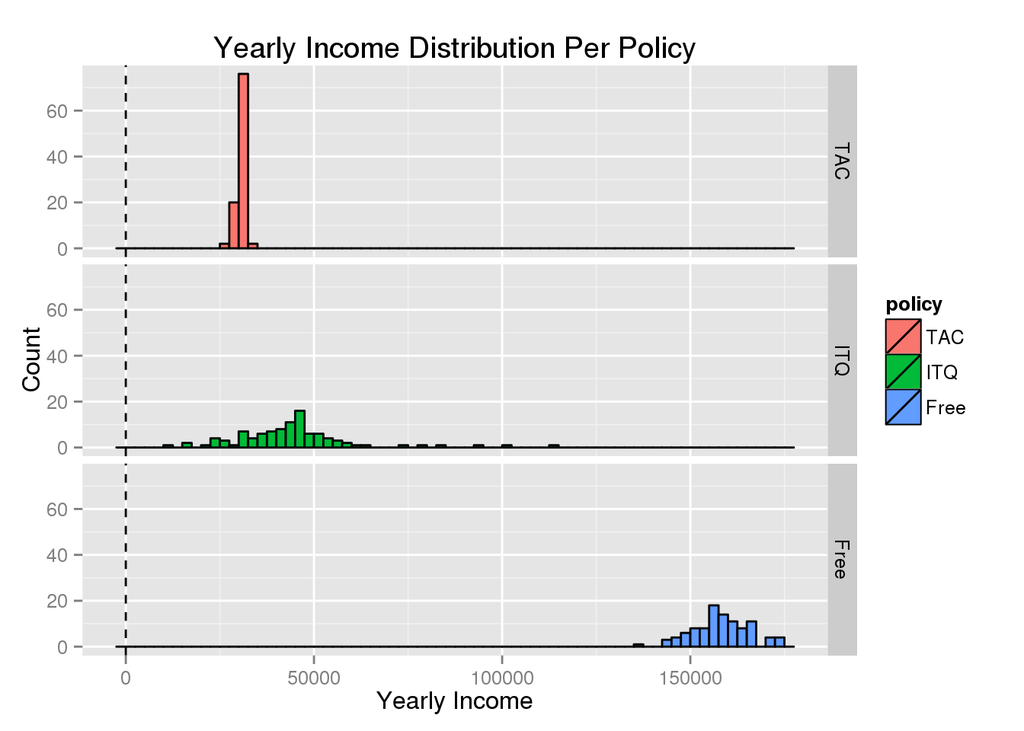

| Policy | Gini Coefficient |
| --- | --- |
| TAC | 0.0177438 |
| ITQ | 0.1776400 |
| Free | 0.0263048 |

Again, this distributional effect of the market is unexpected and I’d like to take my time examining it before shouting “euroka”.